# Вариант 06. Прогнозирование рыночной доли авиакомпании-лоукостера

Валиулин Юрий БЛГ-172

# Задание к контрольной работе по теме «Регрессия»

Ваш номер варианта указан в журнале. Отредактируйте заголовок этого документа, указав там свою фамилию и группу.

В файле `airfare.csv` содержится информация тарифах на авиабилеты. Ваша задача - исследовать, какие факторы влияют на рыночную долю авиакомпании-лоукостера и разработать модель для прогнозирования ее рыночной доли.

Источник: Miscellaneous Datasets, http://www.stat.ufl.edu/~winner/data/airq402.txt

**Описание переменных**

- `Average Fare`: средний тариф
- `Distance`: расстояние
- `Average weekly passengers`: среднее число пассажиров
- `market leading airline`: ведущая авиакомпания
- `market share leading`: доля рынка ведущей компании
- `Average fare leading`: средний тариф ведущей компании
- `Low price airline`: лоукостер
- `market share low`: доля рынка лоукостера - целевая переменная
- `price low`: тариф лоукостера

**Требуется:**

1. Разделите данные выборки случайным образом на два подмножества: обучающую выборку (порядка 80%) и тестовую выборку (порядка 20%). Все дальнейшие операции, кроме финальной проверки модели, проводите с обучающей выборкой.
2. С помощью разведочного анализа и построения модели множественной регрессии в R определите, какие факторы и каким образом влияют на целевую переменную.
3. Исследуйте качество и адекватность полученной вами модели, используя данные обучающей выборки. При необходимости, измените модель или преобразуйте данные так, чтобы проблемы были максимально устранены.
4. Исследуйте выбросы - наблюдения, на которых ваша модель дает большую ошибку. С чем может быть связано наличие этих выбросов? Проверьте, как изменятся результаты моделирования, если эти наблюдения удалить.
5. С помощью своей модели разработайте прогноз для тестовой выборки. Сравните ошибку модели на обучающей и тестовой выборке, используя показатели MAPE и BIAS:

$$MAPE = \frac{1}{n} \sum \left| \frac{y - \hat y}{y} \right|$$

$$BIAS = \frac{1}{n} \frac{\sum (y - \hat y)}{\sum y}$$

Если вы преобразовывали целевую переменную при построении модели, то необходимо сравнивать показатели ошибки на прогнозах, преобразованных обратно в исходную шкалу.

По работе необходимо подготовить отчет в HTML-формате, подробно поясняющий ваши решения в процессе исследования данных, выбора факторов и построения модели, проверки ее адекватности.

Все расчеты, промежуточные и конечные результаты должны сопровождаться пояснениями и выводами. Выводы должны соответствовать полученным результатам. Работа должна быть аккуратно оформлена - содержать заголовки разделов, оглавление. Все графики должны быть подписаны (заголовки, единицы измерения на осях).

Отчет необходимо отправить на проверку через проект в LMS. Присланные другим способом работы не рассматриваются.

При оценке вашей работы ключевым фактором будет качество подготовленного отчета.

## Загрузка необходимых для работы пакетов:

```r
library(readr) # считывание данных из текстовых файлов
library(tidyverse) # манипулирование данными
```

```r
library(ggplot2) # визуализация
library(ggfortify) # визуализация диагностических графиков
library(modelr) # вспомогательные функции для работы с моделями
library(broom) # преобразование результатов моделирования в табличный вид
library(GGally) # построение матрицы диаграмм рассеяния
library(forcats) # работа с факторами
library(tidyr)
library(car)
library(glmnet)
library(memisc) # удобное сравнение моделей в таблице
library (gridExtra)
```

## Загрузка данных авиакомпаний:

```r
library(readxl)
ai <- read_csv("C:/Users/Юра/Desktop/KP-NIS-R/кр регрессия/airfare.csv")
View(ai)
```

## Разведочный анализ:

```r
summary(ai)
```

```
##   Average Fare    Distance    Average weekly passengers market leading airline market share leading
##  Min.   : 51   Min.   : 108   Min.   : 181              Length:1000            Min.   : 17.7
##  1st Qu.:126   1st Qu.: 554   1st Qu.: 257              Class :character       1st Qu.: 46.5
##  Median :161   Median : 919   Median : 405              Mode  :character       Median : 59.2
##  Mean   :163   Mean   :1057   Mean   : 672                                     Mean   : 60.1
##  3rd Qu.:197   3rd Qu.:1452   3rd Qu.: 770                                     3rd Qu.: 73.5
##  Max.   :401   Max.   :2724   Max.   :8951                                     Max.   :100.0
##  Average fare leading Low price airline  market share low   price low
##  Min.   : 51          Length:1000        Min.   :  1.1    Min.   : 50
##  1st Qu.:124          Class :character   1st Qu.: 13.2    1st Qu.:114
##  Median :161          Mode  :character   Median : 26.1    Median :138
##  Mean   :167                             Mean   : 34.6    Mean   :143
##  3rd Qu.:203                             3rd Qu.: 53.0    3rd Qu.:169
##  Max.   :490                             Max.   :100.0    Max.   :388
```

##Создание обучающей выборки (80% от общего)

```r
ai1 <-
  ai %>%
  mutate(id=c(1:1000))

ail <- ai1[ai1$id <= 800,] %>%
  dplyr::select(-id)

ait <- ai1[ai1$id > 800, ] %>%
 dplyr::select(-id)
```

“ail” - обучающая выборка, состоящая из 800 наблюдений, на ее основе будет формироваться регресионная модель “ait” - тестовая выборка, состоящая из 200 наблюдений, на ее основе будет произведена проверка модели.

**Анализ зависимости будущей модели от качесвенных переменных** Т.к. таких всего 2, можно сразу построить несколько графиков зависимостей, которые бы помогли ответить на вопрос: стоит ли учитывать качественные переменные в модели, и если да, то как сильно они влият на значения наблюдений.

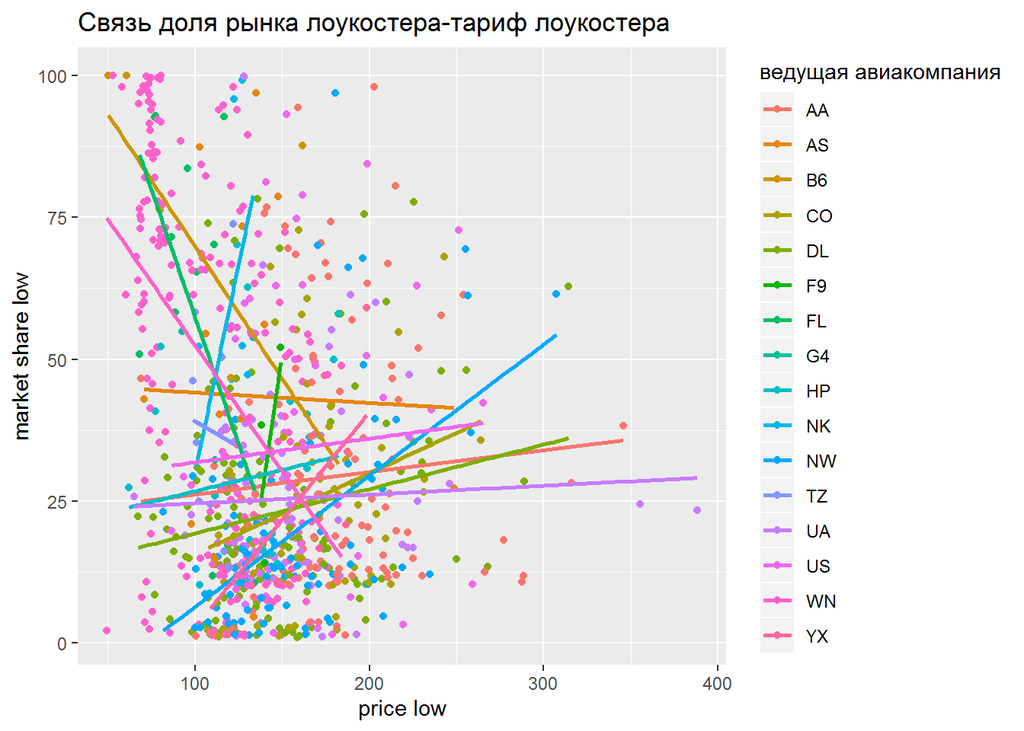

```r
ail %>%
  ggplot(aes(`price low`, `market share low`, color = `market leading airline`)) +
  geom_point() +
  geom_smooth(method = 'lm', se = F)+
  labs(title = "Связь доля рынка лоукостера-тариф лоукостера",
     colour = "ведущая авиакомпания")
```

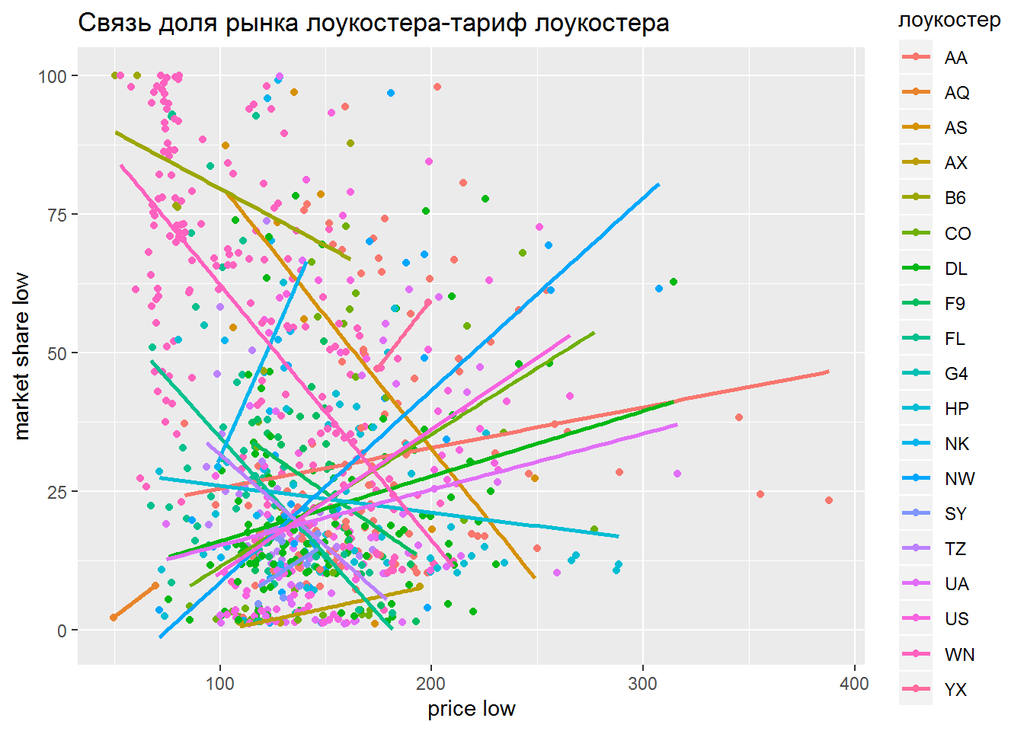

```r
ail %>%
  ggplot(aes(`price low`, `market share low`, color = `Low price airline`)) +
  geom_point() +
  geom_smooth(method = 'lm', se = F)+
  labs(title = "Связь доля рынка лоукостера-тариф лоукостера",
     colour = "лоукостер")
```

Оба графика показывают, что регресионные прямые, в зависимости от каждой авиакомпании существенно различаются (наколны графиков как положительные, так и отрицательные имеют наклоны). Это говорит о том, что данные качественные переменные: ведущая компания и лоукостер необходимо исользовать в модели.

**Построение диаграмм рассеивания и коэффициентов корреляции:**

Для изначального анализа, отберем количественные переменные:

```r
ail_num <- ail %>%
  select_if(is.numeric)
```

также уберем искуственный столбец id, ненужный в анализе.

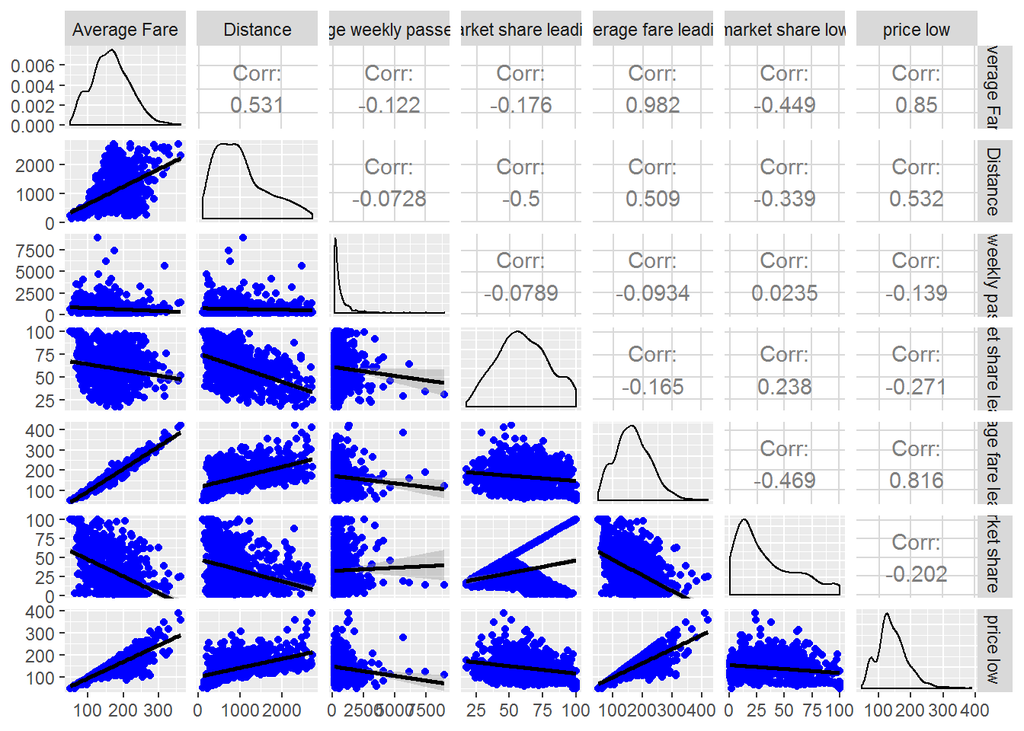

```r
ggpairs(ail_num,
        lower = list(continuous = wrap("smooth_lm", color = 'blue')))
```

`market share low` - целевая переменная. Таблица говорит, что Average fare leading наиболее всех влияет на показание целевой функции, т.к. модуль коэффициента корреляции наибольший.

Построим первую модель, основываясь на самой значимой переменной:

#Модель 1 `market share low` ~ `Average fare leading`

```r
m1 <- lm(`market share low` ~ `Average fare leading`, data = ail)
summary(m1)
```

```
##
## Call:
## lm(formula = `market share low` ~ `Average fare leading`, data = ail)
##
## Residuals:
##    Min     1Q Median     3Q    Max
## -52.45 -17.44  -5.25  15.89  72.09
##
## Coefficients:
##                        Estimate Std. Error t value Pr(>|t|)
## (Intercept)             67.7777     2.4692    27.4   <2e-16 ***
## `Average fare leading`  -0.2067     0.0138   -15.0   <2e-16 ***
## ---
## Signif. codes:  0 '***' 0.001 '**' 0.01 '*' 0.05 '.' 0.1 ' ' 1
##
## Residual standard error: 23.4 on 798 degrees of freedom
## Multiple R-squared:  0.22,   Adjusted R-squared:  0.219
## F-statistic:  224 on 1 and 798 DF,  p-value: <2e-16
```

Модель значима

```r
glance(m1) %>% dplyr::select(r.squared, sigma)
```

```
## # A tibble: 1 x 2
##   r.squared sigma
##       <dbl> <dbl>
## 1     0.220  23.4
```

**Вывод:** Модель объяснила 22% дисперсии исходных данных, ее стандартная ошибка равна 23. несмотря на небольшое стандартное отклонение, модель объяснила только 22% наблюдения, что говорит о ее плохой точности.

Так как данные содержат в себе большое число переменных, перебирать вручную - нецелесообразно. Воспользуемся специальной функцией, которая поочередно добавляет переменные в линейную регрессинную модель.Попутно будет считаться показатель AIC, основанный на сотатках модели, чем меньше показатель, тем лучше модель.

Для этого необходимо создать модель “полную”, включающую все переменные:

```r
m_full <- lm(`market share low` ~ ., data = dplyr::select(ail, `Average Fare`:`price low`)) # Символ . обозначает все переменные в таблице

summary(m_full)
```

```
##
## Call:
## lm(formula = `market share low` ~ ., data = dplyr::select(ail,
##     `Average Fare`:`price low`))
##
## Residuals:
##    Min     1Q Median     3Q    Max
## -59.22 -10.87   0.01  12.09  49.35
##
## Coefficients: (1 not defined because of singularities)
##                              Estimate Std. Error t value Pr(>|t|)
## (Intercept)                  2.75e+01   5.48e+00    5.03  6.2e-07 ***
## `Average Fare`              -2.70e-01   8.02e-02   -3.37  0.00079 ***
## Distance                    -6.37e-03   1.58e-03   -4.04  5.8e-05 ***
## `Average weekly passengers`  6.99e-04   9.70e-04    0.72  0.47136
## `market leading airline`AS  -2.17e+00   6.42e+00   -0.34  0.73527
## `market leading airline`B6  -1.09e+01   1.33e+01   -0.81  0.41604
## `market leading airline`CO  -6.17e+00   3.08e+00   -2.00  0.04563 *
## `market leading airline`DL  -3.99e+00   2.57e+00   -1.56  0.12023
## `market leading airline`F9   9.88e+00   1.12e+01    0.88  0.37944
## `market leading airline`FL   2.27e+01   6.03e+00    3.76  0.00018 ***
## `market leading airline`G4   2.23e+01   1.88e+01    1.18  0.23664
## `market leading airline`HP   2.52e-01   4.69e+00    0.05  0.95715
## `market leading airline`NK   1.56e+01   8.94e+00    1.75  0.08097 .
## `market leading airline`NW  -5.14e+00   2.92e+00   -1.76  0.07841 .
## `market leading airline`TZ   6.99e-01   6.80e+00    0.10  0.91812
## `market leading airline`UA  -1.55e+00   3.10e+00   -0.50  0.61667
## `market leading airline`US   2.99e+00   3.49e+00    0.86  0.39159
## `market leading airline`WN  -1.87e+00   2.80e+00   -0.67  0.50354
## `market leading airline`YX  -7.98e+00   5.75e+00   -1.39  0.16582
## `market share leading`       2.63e-01   4.47e-02    5.89  5.8e-09 ***
## `Average fare leading`      -1.02e-01   6.57e-02   -1.56  0.12002
## `Low price airline`AQ       -3.73e+01   1.35e+01   -2.77  0.00570 **
## `Low price airline`AS        1.77e+01   8.04e+00    2.20  0.02788 *
## `Low price airline`AX       -2.15e+01   1.09e+01   -1.96  0.04996 *
## `Low price airline`B6        4.67e+01   1.53e+01    3.06  0.00227 **
## `Low price airline`CO        9.63e-01   3.73e+00    0.26  0.79635
## `Low price airline`DL       -7.62e+00   2.65e+00   -2.88  0.00409 **
## `Low price airline`F9       -5.22e-01   4.32e+00   -0.12  0.90384
## `Low price airline`FL       -8.40e+00   3.54e+00   -2.38  0.01769 *
## `Low price airline`G4              NA         NA      NA       NA
## `Low price airline`HP       -5.41e+00   3.29e+00   -1.64  0.10079
## `Low price airline`NK        8.69e+00   7.39e+00    1.18  0.23988
## `Low price airline`NW        4.26e+00   3.81e+00    1.12  0.26371
## `Low price airline`SY        2.84e+00   7.67e+00    0.37  0.71176
## `Low price airline`TZ        1.52e+00   4.43e+00    0.34  0.73093
## `Low price airline`UA       -2.90e+00   3.47e+00   -0.84  0.40341
## `Low price airline`US       -1.29e+00   2.97e+00   -0.43  0.66434
## `Low price airline`WN        1.78e+01   2.67e+00    6.67  5.1e-11 ***
## `Low price airline`YX        1.95e+01   1.43e+01    1.37  0.17139
## `price low`                  3.94e-01   3.04e-02   12.97  < 2e-16 ***
## ---
## Signif. codes:  0 '***' 0.001 '**' 0.01 '*' 0.05 '.' 0.1 ' ' 1
##
## Residual standard error: 18.5 on 761 degrees of freedom
## Multiple R-squared:  0.535,  Adjusted R-squared:  0.512
## F-statistic: 23.1 on 38 and 761 DF,  p-value: <2e-16
```

Не все переменные значимы в модели, соответсвенно, “полная” модель - скорее не будет являться лучшей.

И “пустую” модель без переменных: Теперь можно начать перебор с последующим включением переменных:

```r
m_null <- lm(`market share low` ~ 1, data = dplyr::select(ail, `Average Fare`:`price low`))

# Прямое включение
m_forward <- stepAIC(m_null,
                     scope = list(lower = m_null, upper = m_full),
                     direction = 'forward')
```

```
## Start:  AIC=5242
## `market share low` ~ 1
##
##                               Df Sum of Sq    RSS  AIC
## + `Low price airline`         18    152587 406561 5023
## + `Average fare leading`       1    122751 436398 5045
## + `Average Fare`               1    112734 446415 5064
## + `market leading airline`    15    112748 446401 5091
## + Distance                     1     64381 494767 5146
## + `market share leading`       1     31728 527420 5197
## + `price low`                  1     22855 536294 5210
## <none>                                     559148 5242
## + `Average weekly passengers`  1       308 558840 5243
##
## Step:  AIC=5023
## `market share low` ~ `Low price airline`
##
##                               Df Sum of Sq    RSS  AIC
## + `Average fare leading`       1     47592 358969 4925
## + `Average Fare`               1     42538 364023 4936
## + Distance                     1     38622 367940 4945
## + `market leading airline`    14     46771 359791 4953
## + `market share leading`       1     22215 384346 4980
## + `price low`                  1      1836 404725 5021
## <none>                                     406561 5023
## + `Average weekly passengers`  1        79 406483 5025
##
## Step:  AIC=4925
## `market share low` ~ `Low price airline` + `Average fare leading`
##
##                               Df Sum of Sq    RSS  AIC
## + `price low`                  1     44215 314753 4822
## + `market share leading`       1     14751 344218 4894
## + `market leading airline`    14     23831 335138 4898
## + Distance                     1     11799 347170 4900
## + `Average Fare`               1      1070 357899 4925
## <none>                                     358969 4925
## + `Average weekly passengers`  1       134 358835 4927
##
## Step:  AIC=4822
```

[output cut: 34 more lines]

```
##     `price low` + `market share leading` + Distance + `market leading airline`
##
##                               Df Sum of Sq    RSS  AIC
## + `Average Fare`               1      4072 259978 4703
## <none>                                     264050 4713
## + `Average weekly passengers`  1       370 263680 4714
##
## Step:  AIC=4703
## `market share low` ~ `Low price airline` + `Average fare leading` +
##     `price low` + `market share leading` + Distance + `market leading airline` +
##     `Average Fare`
##
##                               Df Sum of Sq    RSS  AIC
## <none>                                     259978 4703
## + `Average weekly passengers`  1       177 259801 4704
```

Наименьший показатель AIC - 4703, построим модель, включающую предлагаемые перемеменные:

#Модель 2 `market share low` ~ `Low price airline` + `Average fare leading` + `price low` + `market share leading` + Distance + `market leading airline` + `Average Fare`

```r
m2 <- lm(`market share low` ~ `Low price airline` + `Average fare leading` +
    `price low` + `market share leading` + Distance + `market leading airline` +
    `Average Fare`, data = ail)
summary(m2)
```

```
##
## Call:
## lm(formula = `market share low` ~ `Low price airline` + `Average fare leading` +
##     `price low` + `market share leading` + Distance + `market leading airline` +
##     `Average Fare`, data = ail)
##
## Residuals:
##    Min     1Q Median     3Q    Max
## -59.32 -10.88   0.09  11.94  49.49
##
## Coefficients: (1 not defined because of singularities)
##                             Estimate Std. Error t value Pr(>|t|)
## (Intercept)                 28.35497    5.36112    5.29  1.6e-07 ***
## `Low price airline`AQ      -36.43682   13.39942   -2.72  0.00669 **
## `Low price airline`AS       17.78833    8.03286    2.21  0.02709 *
## `Low price airline`AX      -21.62336   10.92894   -1.98  0.04823 *
## `Low price airline`B6       46.10828   15.22472    3.03  0.00254 **
## `Low price airline`CO        0.90237    3.72825    0.24  0.80882
## `Low price airline`DL       -7.61906    2.64418   -2.88  0.00407 **
## `Low price airline`F9       -0.41442    4.31834   -0.10  0.92357
## `Low price airline`FL       -8.21518    3.52443   -2.33  0.02002 *
## `Low price airline`G4       22.07924   18.79332    1.17  0.24042
## `Low price airline`HP       -5.32198    3.29063   -1.62  0.10623
## `Low price airline`NK       10.05575    7.14095    1.41  0.15949
## `Low price airline`NW        4.21718    3.80681    1.11  0.26830
## `Low price airline`SY        3.12018    7.65829    0.41  0.68381
## `Low price airline`TZ        2.27760    4.29844    0.53  0.59636
## `Low price airline`UA       -3.00572    3.46852   -0.87  0.38645
## `Low price airline`US       -1.30528    2.97196   -0.44  0.66064
## `Low price airline`WN       17.87640    2.66019    6.72  3.6e-11 ***
## `Low price airline`YX       19.71262   14.26663    1.38  0.16746
## `Average fare leading`      -0.09694    0.06526   -1.49  0.13781
## `price low`                  0.39375    0.03038   12.96  < 2e-16 ***
## `market share leading`       0.26077    0.04456    5.85  7.2e-09 ***
## Distance                    -0.00646    0.00157   -4.11  4.3e-05 ***
## `market leading airline`AS  -2.16122    6.42069   -0.34  0.73651
## `market leading airline`B6 -10.08236   13.29181   -0.76  0.44836
## `market leading airline`CO  -6.30889    3.07754   -2.05  0.04071 *
## `market leading airline`DL  -4.01212    2.56729   -1.56  0.11852
## `market leading airline`F9   9.90847   11.22718    0.88  0.37776
## `market leading airline`FL  22.32255    6.00850    3.72  0.00022 ***
## `market leading airline`G4        NA         NA      NA       NA
## `market leading airline`HP   0.19600    4.69167    0.04  0.96669
## `market leading airline`NK  14.41238    8.77568    1.64  0.10094
## `market leading airline`NW  -5.38408    2.89878   -1.86  0.06365 .
## `market leading airline`TZ   0.47089    6.79071    0.07  0.94473
## `market leading airline`UA  -1.62968    3.09641   -0.53  0.59882
## `market leading airline`US   2.86790    3.48333    0.82  0.41058
## `market leading airline`WN  -1.96498    2.79255   -0.70  0.48186
## `market leading airline`YX  -8.27274    5.73550   -1.44  0.14961
## `Average Fare`              -0.27571    0.07980   -3.45  0.00058 ***
## ---
## Signif. codes:  0 '***' 0.001 '**' 0.01 '*' 0.05 '.' 0.1 ' ' 1
##
## Residual standard error: 18.5 on 762 degrees of freedom
## Multiple R-squared:  0.535,  Adjusted R-squared:  0.512
## F-statistic: 23.7 on 37 and 762 DF,  p-value: <2e-16
```

Коэффициенты модели частично не значимы (например: `Average fare leading` ), в остальном все переменные значимы хотя бы в одном коэффициенте. Также, R^2 находится в допустимом диапозоне (т.к. частично это схожий показатель с AIC, по которому производился отбор модели). Значит, несмотряна громоздкость модели она не столь сложна.

Графики рассеяния:

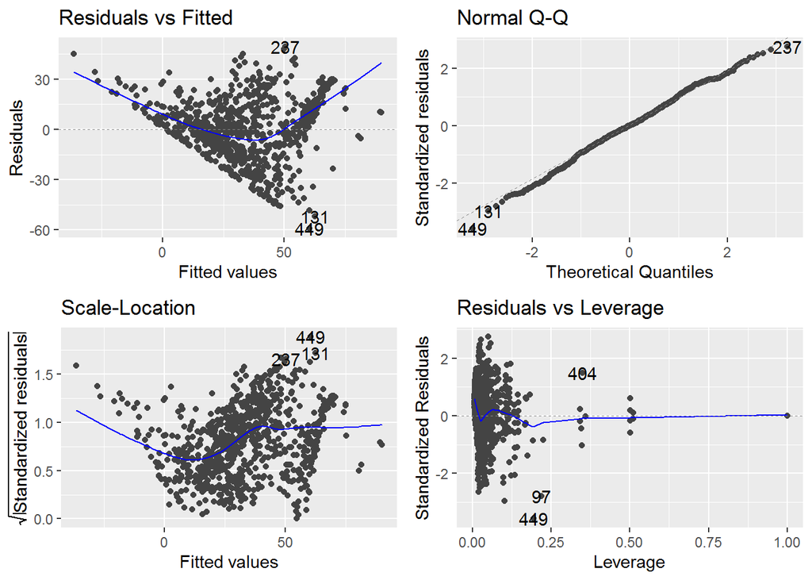

```r
autoplot(m2)
```

Графики говорят о наличии нелинейной связи и гетероскедастичности. Leverage для данной выборки = 0,03. Как видно подовляющее бльшинство наблюдений выходят за допустимые границы (однако, некоторые считают допустимые пределы до 1). В любом случае игнорировать или изменять столь большое количество наблюдений - нецелесообразно.

Так как графики сотатков распределены нормально, скорее необходимо преобразовать зависимую переменную, изменение независимых не приведет к улучшению ситуации.

Расчитаем необходимое преобразование для зависимой переменной.

```r
t1 <- car::powerTransform(`market share low` ~ `Low price airline`  + `Average fare leading` +  +
    `price low`  + `market share leading`  + Distance + `market leading airline` +
    `Average Fare`, data = ail)
coef(t1)
```

```
##    Y1
## 0.295
```

Возведем “Y” в степень.

#Модель 2.1 = модель2 Y^0.295

```r
m21 <- lm(`market share low`^0.295 ~ `Low price airline`  + `Average fare leading` +
    `price low` + `market share leading`  + Distance + `market leading airline` +
    `Average Fare`, data = ail)
summary(m21)
```

```
##
## Call:
## lm(formula = `market share low`^0.295 ~ `Low price airline` +
##     `Average fare leading` + `price low` + `market share leading` +
##     Distance + `market leading airline` + `Average Fare`, data = ail)
##
## Residuals:
##     Min      1Q  Median      3Q     Max
## -1.8824 -0.2946  0.0209  0.3361  1.4410
##
## Coefficients: (1 not defined because of singularities)
##                             Estimate Std. Error t value Pr(>|t|)
## (Intercept)                 3.08e+00   1.46e-01   21.07  < 2e-16 ***
## `Low price airline`AQ      -9.53e-01   3.65e-01   -2.61  0.00917 **
## `Low price airline`AS       3.52e-01   2.19e-01    1.61  0.10840
## `Low price airline`AX      -8.33e-01   2.98e-01   -2.80  0.00527 **
## `Low price airline`B6       1.02e+00   4.15e-01    2.46  0.01427 *
## `Low price airline`CO      -7.29e-02   1.02e-01   -0.72  0.47269
## `Low price airline`DL      -1.92e-01   7.20e-02   -2.67  0.00769 **
## `Low price airline`F9      -8.85e-04   1.18e-01   -0.01  0.99400
## `Low price airline`FL      -1.64e-01   9.60e-02   -1.71  0.08755 .
## `Low price airline`G4       7.08e-01   5.12e-01    1.38  0.16689
## `Low price airline`HP      -3.44e-02   8.96e-02   -0.38  0.70096
## `Low price airline`NK       3.12e-01   1.94e-01    1.60  0.10944
## `Low price airline`NW      -6.87e-04   1.04e-01   -0.01  0.99471
## `Low price airline`SY       1.22e-01   2.09e-01    0.58  0.56002
## `Low price airline`TZ       6.10e-02   1.17e-01    0.52  0.60239
## `Low price airline`UA      -1.34e-01   9.45e-02   -1.42  0.15743
## `Low price airline`US      -1.02e-01   8.09e-02   -1.26  0.20955
## `Low price airline`WN       4.84e-01   7.24e-02    6.68  4.7e-11 ***
## `Low price airline`YX       6.11e-01   3.89e-01    1.57  0.11633
## `Average fare leading`     -2.10e-04   1.78e-03   -0.12  0.90585
## `price low`                 1.29e-02   8.27e-04   15.56  < 2e-16 ***
## `market share leading`     -2.67e-03   1.21e-03   -2.20  0.02830 *
## Distance                   -2.51e-04   4.28e-05   -5.88  6.3e-09 ***
## `market leading airline`AS -1.00e-02   1.75e-01   -0.06  0.95431
## `market leading airline`B6 -9.52e-02   3.62e-01   -0.26  0.79267
## `market leading airline`CO -1.60e-01   8.38e-02   -1.91  0.05632 .
## `market leading airline`DL -7.59e-02   6.99e-02   -1.09  0.27787
## `market leading airline`F9  2.42e-01   3.06e-01    0.79  0.42933
## `market leading airline`FL  5.63e-01   1.64e-01    3.44  0.00062 ***
## `market leading airline`G4        NA         NA      NA       NA
## `market leading airline`HP -7.70e-04   1.28e-01   -0.01  0.99519
## `market leading airline`NK  3.50e-01   2.39e-01    1.46  0.14380
## `market leading airline`NW -1.12e-01   7.89e-02   -1.42  0.15695
## `market leading airline`TZ  7.27e-02   1.85e-01    0.39  0.69415
## `market leading airline`UA -4.32e-02   8.43e-02   -0.51  0.60882
## `market leading airline`US  1.01e-01   9.49e-02    1.06  0.28830
## `market leading airline`WN -6.20e-02   7.61e-02   -0.82  0.41504
## `market leading airline`YX -3.60e-01   1.56e-01   -2.31  0.02140 *
## `Average Fare`             -1.15e-02   2.17e-03   -5.31  1.4e-07 ***
## ---
## Signif. codes:  0 '***' 0.001 '**' 0.01 '*' 0.05 '.' 0.1 ' ' 1
##
## Residual standard error: 0.503 on 762 degrees of freedom
## Multiple R-squared:  0.537,  Adjusted R-squared:  0.515
## F-statistic: 23.9 on 37 and 762 DF,  p-value: <2e-16
```

Графики рассеяния:

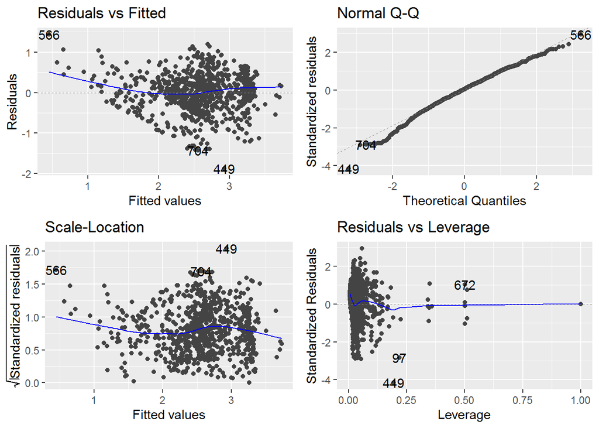

```r
autoplot(m21)
```

Рапсределения остаток стало нормальнее. (Их улучшение не удалось достич иными изменениями X или Y) Leverage = 3*кол-во исследуемых переменных/объем выборки Leverage = 0,03 Огромное число наблюдений выходит за максимальную границу, это значит, что раз такое множество значений существенны, возможно необходимо использовать взаимосвязи переменных.

Также, обратим внимание на незначимые переменные и уберем их из модели (`Average fare leading` )

Стоит обратить внимание на такой факт: переменные market leading airline и Low price airline - качественные, они состоят из набора названий компаний, которые повторяются в обеих. Возможно, как и предполагалось, стоит рассматривать их не как отдельные переменные, а в взаимосвязи с другими количественными переменными.

#Модель 3 `market share low`^0.295 ~ `Low price airline`*`price low`+ `market leading airline`*`Average Fare` + `price low` + `market share leading` + Distance +  
`Average Fare`

```r
m3 <- lm(`market share low`^0.295 ~ `Low price airline`*`price low`+ `market leading airline`*`Average Fare`   +
    `price low` + `market share leading`  + Distance +
    `Average Fare`, data = ail)
summary(m3)
```

```
##
## Call:
## lm(formula = `market share low`^0.295 ~ `Low price airline` *
##     `price low` + `market leading airline` * `Average Fare` +
##     `price low` + `market share leading` + Distance + `Average Fare`,
##     data = ail)
##
## Residuals:
##     Min      1Q  Median      3Q     Max
## -1.4635 -0.2776  0.0042  0.3013  1.3715
##
## Coefficients: (3 not defined because of singularities)
##                                            Estimate Std. Error t value Pr(>|t|)
## (Intercept)                                2.81e+00   2.73e-01   10.30  < 2e-16 ***
## `Low price airline`AQ                     -2.46e+00   2.00e+00   -1.23  0.21799
## `Low price airline`AS                      3.34e+00   8.56e-01    3.89  0.00011 ***
## `Low price airline`AX                     -6.80e-01   1.11e+00   -0.61  0.54161
## `Low price airline`B6                      1.13e+00   2.88e+00    0.39  0.69544
## `Low price airline`CO                     -7.03e-01   3.49e-01   -2.01  0.04438 *
## `Low price airline`DL                     -5.61e-01   2.56e-01   -2.19  0.02899 *
## `Low price airline`F9                      7.31e-01   6.30e-01    1.16  0.24623
## `Low price airline`FL                      2.55e-01   4.08e-01    0.62  0.53223
## `Low price airline`G4                      8.04e-01   4.76e-01    1.69  0.09157 .
## `Low price airline`HP                      1.28e-01   2.96e-01    0.43  0.66673
## `Low price airline`NK                     -1.08e+00   1.42e+00   -0.76  0.44800
## `Low price airline`NW                     -9.95e-01   3.41e-01   -2.92  0.00363 **
## `Low price airline`SY                      7.08e-01   2.64e+00    0.27  0.78872
## `Low price airline`TZ                      3.99e-01   6.01e-01    0.66  0.50654
## `Low price airline`UA                     -3.14e-01   3.29e-01   -0.96  0.33977
## `Low price airline`US                     -1.04e+00   2.98e-01   -3.50  0.00050 ***
## `Low price airline`WN                      1.93e+00   2.70e-01    7.16  2.0e-12 ***
## `Low price airline`YX                     -5.99e-01   5.07e+00   -0.12  0.90596
## `price low`                                1.16e-02   1.21e-03    9.59  < 2e-16 ***
## `market leading airline`AS                -1.64e+00   7.24e-01   -2.27  0.02368 *
## `market leading airline`B6                 1.34e-01   2.91e+00    0.05  0.96330
## `market leading airline`CO                 4.98e-02   3.79e-01    0.13  0.89539
## `market leading airline`DL                 2.10e-01   2.79e-01    0.75  0.45193
## `market leading airline`F9                 1.51e+00   3.34e+00    0.45  0.65157
## `market leading airline`FL                 2.65e+00   8.61e-01    3.07  0.00220 **
## `market leading airline`G4                       NA         NA      NA       NA
```

[output cut: 35 more lines]

```
## `market leading airline`G4:`Average Fare`        NA         NA      NA       NA
## `market leading airline`HP:`Average Fare`  8.88e-03   3.25e-03    2.73  0.00646 **
## `market leading airline`NK:`Average Fare` -2.64e-03   1.45e-02   -0.18  0.85513
## `market leading airline`NW:`Average Fare`  2.30e-03   1.75e-03    1.32  0.18839
## `market leading airline`TZ:`Average Fare` -7.29e-03   1.51e-02   -0.48  0.62988
## `market leading airline`UA:`Average Fare` -3.40e-04   1.67e-03   -0.20  0.83904
## `market leading airline`US:`Average Fare` -8.67e-03   2.07e-03   -4.19  3.2e-05 ***
## `market leading airline`WN:`Average Fare`  2.09e-03   1.78e-03    1.17  0.24252
## `market leading airline`YX:`Average Fare` -6.43e-03   6.81e-03   -0.95  0.34480
## ---
## Signif. codes:  0 '***' 0.001 '**' 0.01 '*' 0.05 '.' 0.1 ' ' 1
##
## Residual standard error: 0.459 on 732 degrees of freedom
## Multiple R-squared:  0.63,   Adjusted R-squared:  0.596
## F-statistic: 18.6 on 67 and 732 DF,  p-value: <2e-16
```

Каждая переменная значитма хотя бы в одном коэффициенте. Так как взаимосвязей между переменными можно сделать большое множество, продолжим исследование качесвенных переменных на наличие отличий в регрессонных графиках.

**Ведущая авиакомпания**

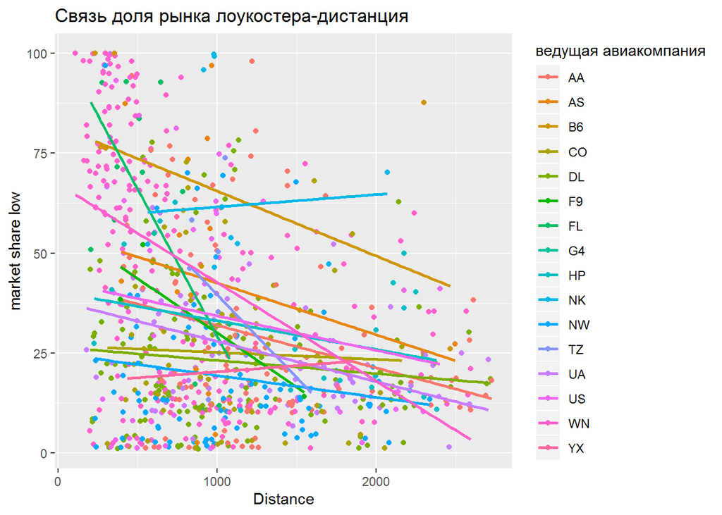

```r
ail %>%
  ggplot(aes(`Distance`, `market share low`, color = `market leading airline`)) +
  geom_point() +
  geom_smooth(method = 'lm', se = F)+
  labs(title = "Связь доля рынка лоукостера-дистанция",
     colour = "ведущая авиакомпания")
```

Регрессионный прямые для разных компаний примерно одинаковы, в цлоем имеют схожие наклоны, скорее взяимосвяз этих факторов можно не рассматривать.

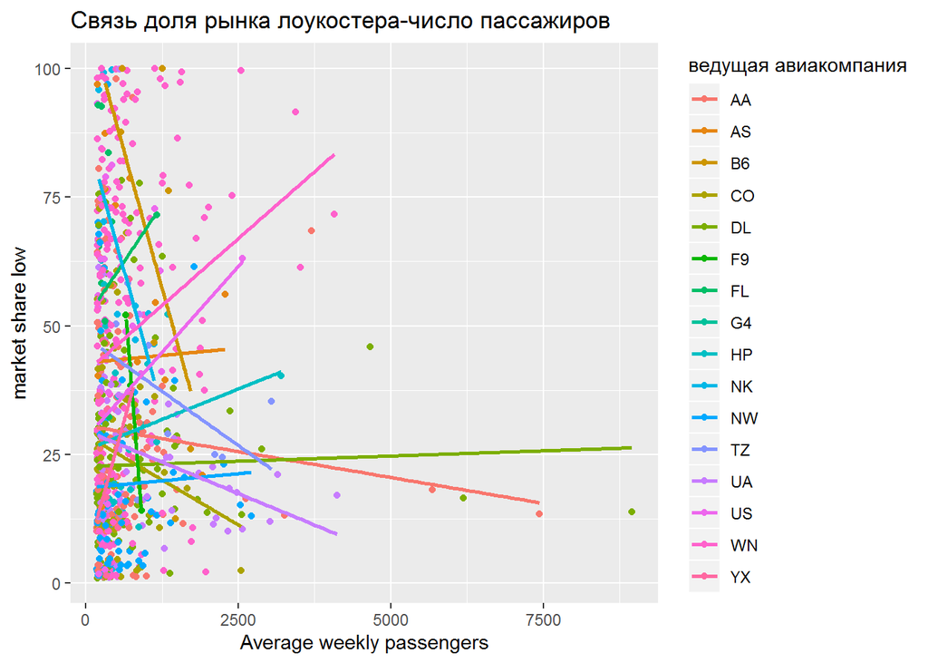

```r
ail %>%
  ggplot(aes(`Average weekly passengers`, `market share low`, color = `market leading airline`)) +
  geom_point() +
  geom_smooth(method = 'lm', se = F)+
  labs(title = "Связь доля рынка лоукостера-число пассажиров",
     colour = "ведущая авиакомпания")
```

Число пассадиров находится в достаточно узком пррмежутке,следовательно паттерны, основанные на выбросах, не дают объективную оценку.

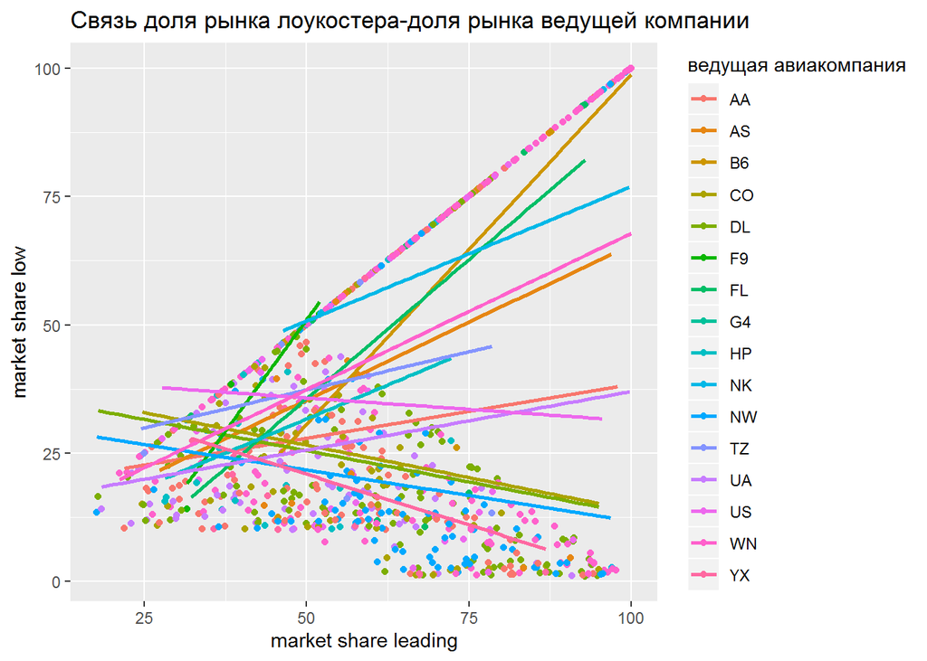

```r
ail %>%
  ggplot(aes(`market share leading`, `market share low`, color = `market leading airline`)) +
  geom_point() +
  geom_smooth(method = 'lm', se = F)+
  labs(title = "Связь доля рынка лоукостера-доля рынка ведущей компании",
     colour = "ведущая авиакомпания")
```

Графики достаточно сильно отличаются по наклонам, что гооврит о возможности рассмотрения взаимосвязи.

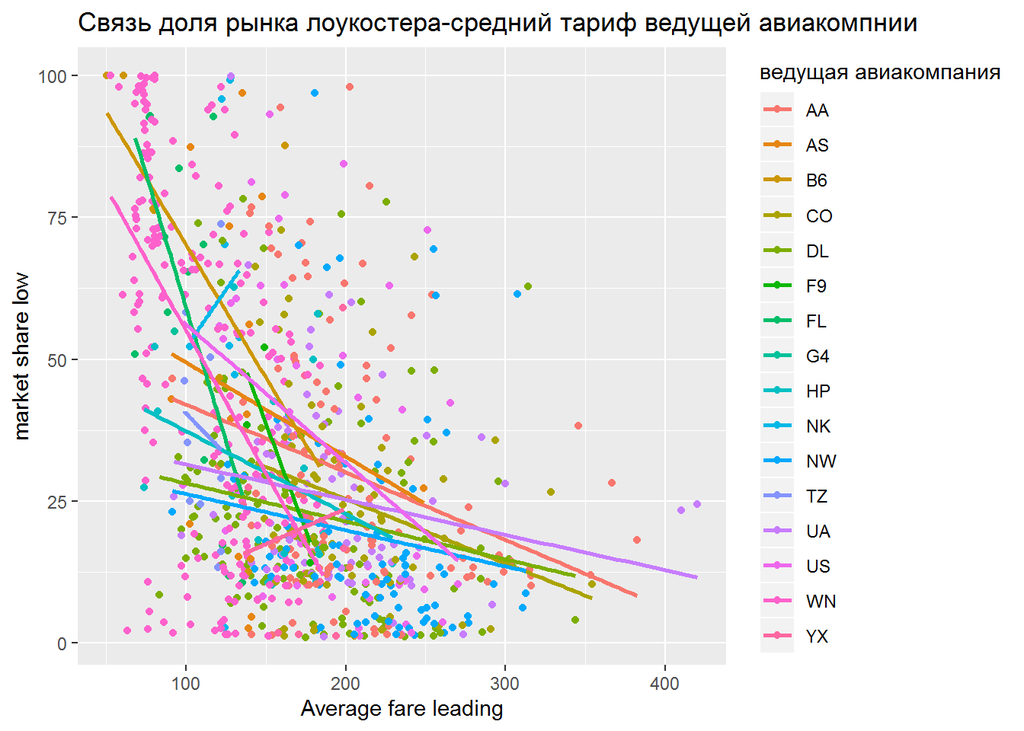

```r
ail %>%
  ggplot(aes(`Average fare leading`, `market share low`, color = `market leading airline`)) +
  geom_point() +
  geom_smooth(method = 'lm', se = F)+
  labs(title = "Связь доля рынка лоукостера-средний тариф ведущей авиакомпнии",
     colour = "ведущая авиакомпания")
```

Большинство прямых имеют похожее положение на графике, те, которые выбиваются, скорее всего имеют недостаточное количество наблюдений.

**Лоукостер**

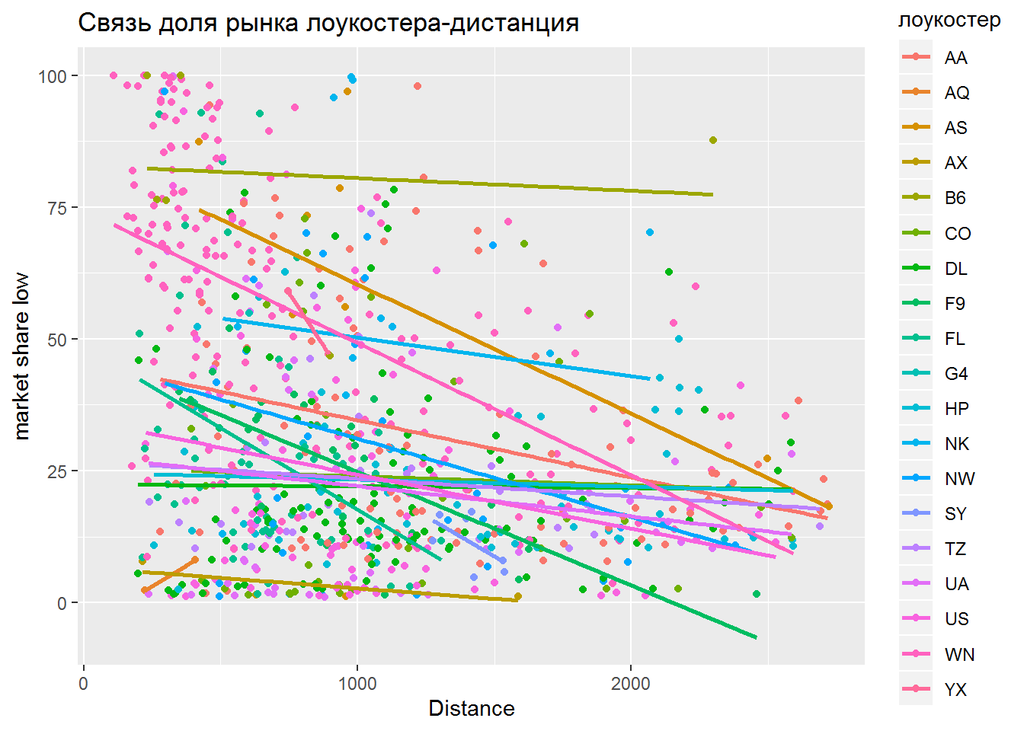

```r
ail %>%
  ggplot(aes(`Distance`, `market share low`, color = `Low price airline`)) +
  geom_point() +
  geom_smooth(method = 'lm', se = F)+
  labs(title = "Связь доля рынка лоукостера-дистанция",
     colour = "лоукостер")
```

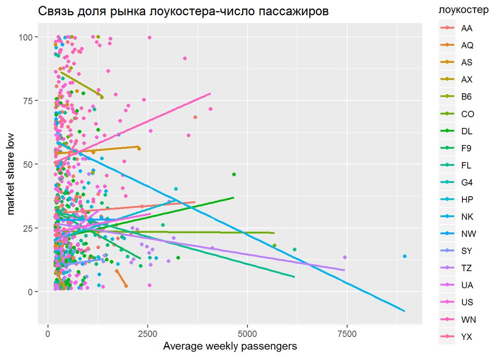

```r
ail %>%
  ggplot(aes(`Average weekly passengers`, `market share low`, color = `Low price airline`)) +
  geom_point() +
  geom_smooth(method = 'lm', se = F)+
  labs(title = "Связь доля рынка лоукостера-число пассажиров",
     colour = "лоукостер")
```

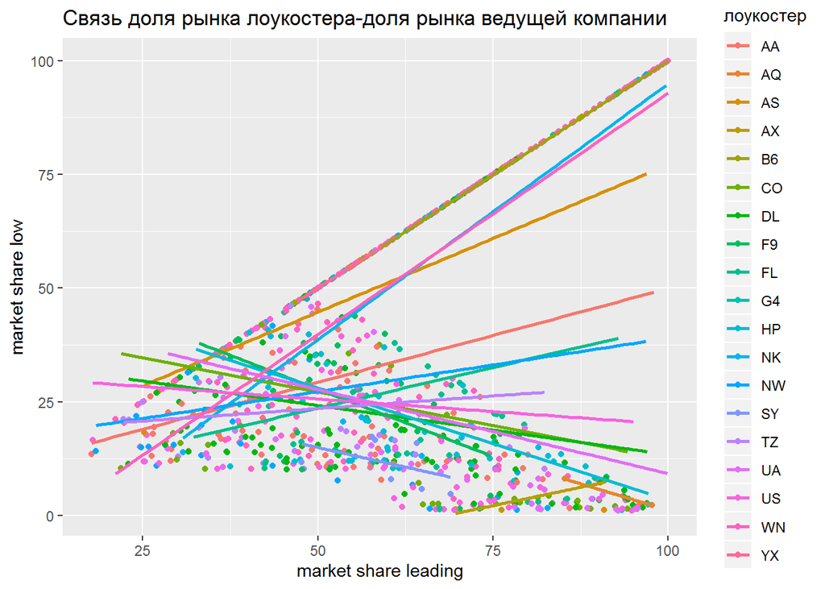

```r
ail %>%
  ggplot(aes(`market share leading`, `market share low`, color = `Low price airline`)) +
  geom_point() +
  geom_smooth(method = 'lm', se = F)+
  labs(title = "Связь доля рынка лоукостера-доля рынка ведущей компании",
     colour = "лоукостер")
```

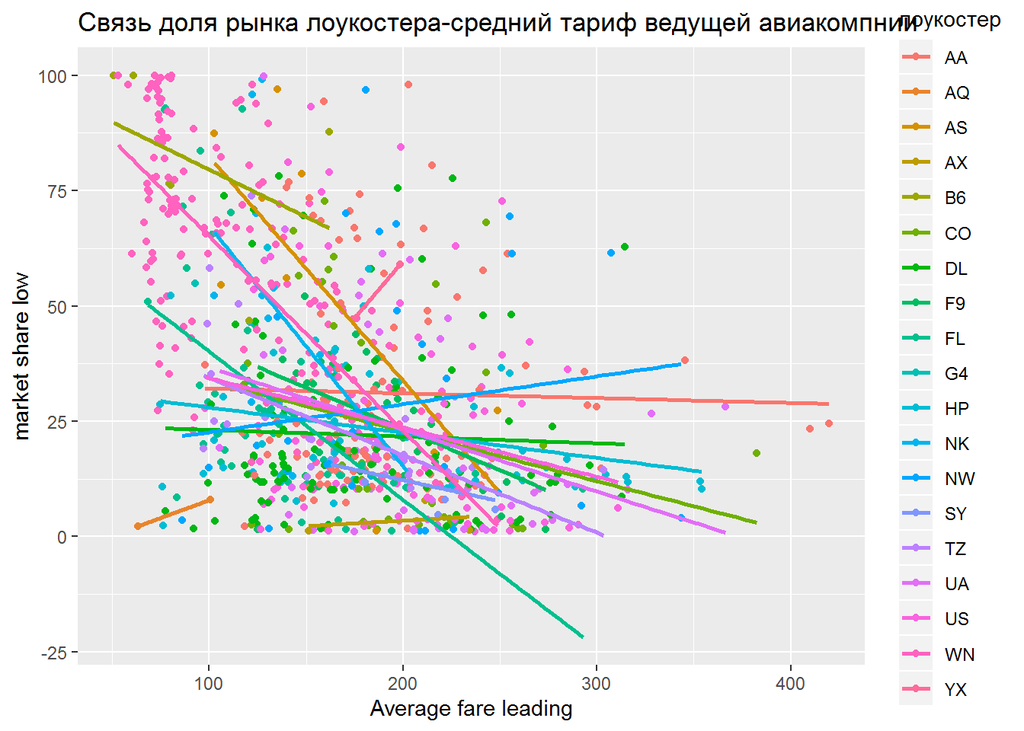

```r
ail %>%
  ggplot(aes(`Average fare leading`, `market share low`, color = `Low price airline`)) +
  geom_point() +
  geom_smooth(method = 'lm', se = F)+
  labs(title = "Связь доля рынка лоукостера-средний тариф ведущей авиакомпнии",
     colour = "лоукостер")
```

Как итог можно сказать: имеет смысл посмотреть взаимосвязь `low price airline` с `market share leading` и `Distance`

#Модель 4

```r
m4 <- lm(`market share low`^0.295 ~  `Low price airline`+
    `price low` + `market share leading`  + Distance + `market leading airline` +
    `Average Fare` + `Low price airline`*`market share leading` + `Low price airline`*Distance + `market share leading`*`market leading airline` , data = ail)
summary(m4)
```

```
##
## Call:
## lm(formula = `market share low`^0.295 ~ `Low price airline` +
##     `price low` + `market share leading` + Distance + `market leading airline` +
##     `Average Fare` + `Low price airline` * `market share leading` +
##     `Low price airline` * Distance + `market share leading` *
##     `market leading airline`, data = ail)
##
## Residuals:
##    Min     1Q Median     3Q    Max
## -1.740 -0.229  0.051  0.207  1.375
##
## Coefficients: (6 not defined because of singularities)
##                                                    Estimate Std. Error t value Pr(>|t|)
## (Intercept)                                        2.61e+00   2.84e-01    9.16  < 2e-16 ***
## `Low price airline`AQ                              4.13e+00   4.68e+00    0.88  0.37722
## `Low price airline`AS                              2.81e+00   1.21e+00    2.31  0.02095 *
## `Low price airline`AX                              1.77e+00   2.94e+00    0.60  0.54703
## `Low price airline`B6                              1.37e+00   1.66e+00    0.82  0.40970
## `Low price airline`CO                              1.11e+00   5.19e-01    2.13  0.03342 *
## `Low price airline`DL                              6.04e-01   3.52e-01    1.72  0.08630 .
## `Low price airline`F9                              1.24e+00   5.14e-01    2.40  0.01653 *
## `Low price airline`FL                              1.24e+00   4.89e-01    2.53  0.01158 *
## `Low price airline`G4                              7.77e-01   4.56e-01    1.70  0.08876 .
## `Low price airline`HP                              1.34e+00   5.23e-01    2.56  0.01060 *
## `Low price airline`NK                             -1.12e+00   6.41e-01   -1.74  0.08217 .
## `Low price airline`NW                              5.44e-02   4.46e-01    0.12  0.90307
## `Low price airline`SY                             -9.51e-01   2.58e+00   -0.37  0.71251
## `Low price airline`TZ                             -4.26e-01   4.63e-01   -0.92  0.35739
## `Low price airline`UA                              1.41e+00   4.48e-01    3.15  0.00169 **
## `Low price airline`US                              3.78e-01   3.82e-01    0.99  0.32265
## `Low price airline`WN                             -5.17e-01   3.26e-01   -1.59  0.11292
## `Low price airline`YX                              2.93e-02   2.87e+00    0.01  0.99188
## `price low`                                        1.20e-02   7.93e-04   15.13  < 2e-16 ***
## `market share leading`                             3.22e-03   3.62e-03    0.89  0.37361
## Distance                                          -2.35e-04   8.66e-05   -2.71  0.00683 **
## `market leading airline`AS                        -7.32e-01   5.15e-01   -1.42  0.15581
## `market leading airline`B6                        -1.40e+00   1.43e+00   -0.98  0.32685
## `market leading airline`CO                         1.23e-01   2.88e-01    0.43  0.67046
## `market leading airline`DL                         2.26e-01   2.18e-01    1.03  0.30114
```

[output cut: 54 more lines]

```
## `market share leading`:`market leading airline`G4        NA         NA      NA       NA
## `market share leading`:`market leading airline`HP -3.93e-03   9.45e-03   -0.42  0.67769
## `market share leading`:`market leading airline`NK -1.33e-02   9.86e-03   -1.35  0.17836
## `market share leading`:`market leading airline`NW -6.37e-04   4.38e-03   -0.15  0.88432
## `market share leading`:`market leading airline`TZ -3.45e-03   9.55e-03   -0.36  0.71813
## `market share leading`:`market leading airline`UA  5.47e-03   4.57e-03    1.20  0.23150
## `market share leading`:`market leading airline`US -5.86e-03   4.87e-03   -1.20  0.22940
## `market share leading`:`market leading airline`WN -9.05e-03   3.71e-03   -2.44  0.01508 *
## `market share leading`:`market leading airline`YX -1.31e-02   9.02e-03   -1.45  0.14774
## ---
## Signif. codes:  0 '***' 0.001 '**' 0.01 '*' 0.05 '.' 0.1 ' ' 1
##
## Residual standard error: 0.447 on 717 degrees of freedom
## Multiple R-squared:  0.657,  Adjusted R-squared:  0.618
## F-statistic: 16.7 on 82 and 717 DF,  p-value: <2e-16
```

Появилось много незначимых переменных и коэффициентов. Убираем взаимосвязи с дистанцией

#Модель4.1

```r
m41 <- lm(`market share low`^0.295 ~  `Low price airline`+
    `price low`  + Distance + `market leading airline` +
    `Average Fare` + `Low price airline`*`market share leading`  , data = ail)
summary(m41)
```

```
##
## Call:
## lm(formula = `market share low`^0.295 ~ `Low price airline` +
##     `price low` + Distance + `market leading airline` + `Average Fare` +
##     `Low price airline` * `market share leading`, data = ail)
##
## Residuals:
##    Min     1Q Median     3Q    Max
## -1.989 -0.265  0.063  0.225  1.708
##
## Coefficients: (2 not defined because of singularities)
##                                               Estimate Std. Error t value Pr(>|t|)
## (Intercept)                                   2.82e+00   1.93e-01   14.62  < 2e-16 ***
## `Low price airline`AQ                         4.46e+00   4.75e+00    0.94  0.34823
## `Low price airline`AS                         2.89e-01   4.62e-01    0.63  0.53195
## `Low price airline`AX                         4.66e-01   2.36e+00    0.20  0.84339
## `Low price airline`B6                         8.90e-02   9.26e-01    0.10  0.92348
## `Low price airline`CO                         7.81e-01   3.00e-01    2.61  0.00932 **
## `Low price airline`DL                         8.25e-01   2.08e-01    3.96  8.2e-05 ***
## `Low price airline`F9                         8.83e-01   4.65e-01    1.90  0.05794 .
## `Low price airline`FL                         1.54e-01   3.08e-01    0.50  0.61727
## `Low price airline`G4                         7.47e-01   4.60e-01    1.62  0.10461
## `Low price airline`HP                         1.42e+00   3.12e-01    4.54  6.6e-06 ***
## `Low price airline`NK                        -3.54e-01   3.78e-01   -0.94  0.34830
## `Low price airline`NW                         1.85e-01   2.63e-01    0.70  0.48252
## `Low price airline`SY                        -1.22e+00   1.65e+00   -0.74  0.46102
## `Low price airline`TZ                        -9.30e-02   2.97e-01   -0.31  0.75412
## `Low price airline`UA                         9.05e-01   2.95e-01    3.06  0.00226 **
## `Low price airline`US                         2.53e-01   2.35e-01    1.08  0.28062
## `Low price airline`WN                        -3.74e-01   1.93e-01   -1.94  0.05281 .
## `Low price airline`YX                         5.48e-01   2.88e+00    0.19  0.84922
## `price low`                                   1.19e-02   7.70e-04   15.51  < 2e-16 ***
## Distance                                     -2.68e-04   3.94e-05   -6.82  1.9e-11 ***
## `market leading airline`AS                    4.01e-02   1.58e-01    0.25  0.80019
## `market leading airline`B6                   -1.67e-01   3.28e-01   -0.51  0.61004
## `market leading airline`CO                   -1.00e-01   7.56e-02   -1.33  0.18458
## `market leading airline`DL                   -2.89e-02   6.48e-02   -0.45  0.65569
## `market leading airline`F9                    5.91e-02   2.77e-01    0.21  0.83131
## `market leading airline`FL                    6.76e-01   1.49e-01    4.52  7.1e-06 ***
## `market leading airline`G4                          NA         NA      NA       NA
```

[output cut: 19 more lines]

```
## `Low price airline`HP:`market share leading` -2.43e-02   5.10e-03   -4.77  2.2e-06 ***
## `Low price airline`NK:`market share leading`  1.23e-02   6.67e-03    1.84  0.06652 .
## `Low price airline`NW:`market share leading` -3.80e-03   4.58e-03   -0.83  0.40614
## `Low price airline`SY:`market share leading`  2.12e-02   2.73e-02    0.78  0.43800
## `Low price airline`TZ:`market share leading`  2.98e-03   5.75e-03    0.52  0.60483
## `Low price airline`UA:`market share leading` -1.67e-02   4.56e-03   -3.66  0.00028 ***
## `Low price airline`US:`market share leading` -6.87e-03   3.87e-03   -1.77  0.07672 .
## `Low price airline`WN:`market share leading`  1.31e-02   3.24e-03    4.05  5.7e-05 ***
## `Low price airline`YX:`market share leading`  2.84e-03   5.39e-02    0.05  0.95794
## ---
## Signif. codes:  0 '***' 0.001 '**' 0.01 '*' 0.05 '.' 0.1 ' ' 1
##
## Residual standard error: 0.454 on 746 degrees of freedom
## Multiple R-squared:  0.632,  Adjusted R-squared:  0.606
## F-statistic: 24.2 on 53 and 746 DF,  p-value: <2e-16
```

Убрали некоторые незначимые переменные и взаимосвязи

Посмотрим графики рассеяния данной модели.

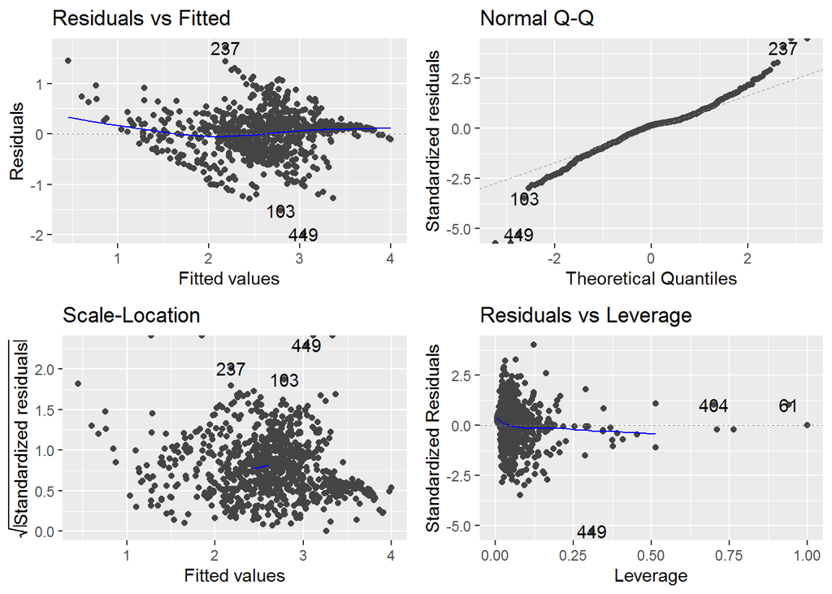

```r
autoplot(m41)
```

Графики стали хуже.

Попробуем исправить положение новым изменением Y (изменения X не дают результатов)

```r
t2<- car::powerTransform(`market share low` ~  `Low price airline`+
    `price low`  + Distance + `market leading airline` +
    `Average Fare` + `Low price airline`*`market share leading`  , data = ail)
coef(t2)
```

```
##    Y1
## 0.309
```

#Модель 4.1.1

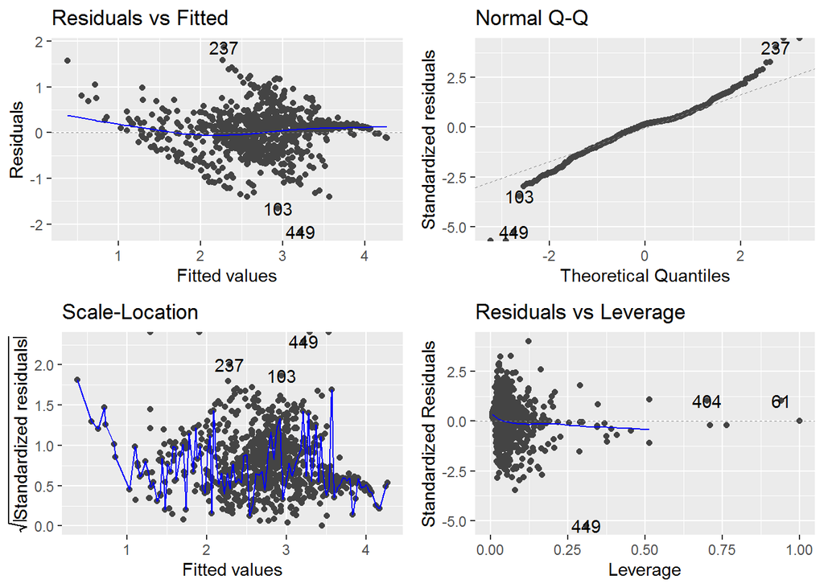

```r
m411 <- lm(`market share low`^0.309 ~  `Low price airline`+
    `price low`  + Distance + `market leading airline` +
    `Average Fare` + `Low price airline`*`market share leading`  , data = ail)
autoplot(m411)
```

##Выбор лучщей модели

**Прогноз обущающий**

```r
pmcdl1 <-
  ail %>%
  add_predictions(m1, var = "Predicted") %>%
  dplyr::select(`market share low`, Predicted)

pmcdl2 <-
  ail %>%
  add_predictions(m2, var = "Predicted") %>%
  dplyr::select(`market share low`, Predicted)


  pmcdl21 <-
  ail %>%
  add_predictions(m21, var = "Predicted") %>%
  dplyr::select(`market share low`, Predicted) %>%
   mutate(Predicted = Predicted^(1/0.295))

   pmcdl3 <-
  ail %>%
  add_predictions(m3, var = "Predicted") %>%
  dplyr::select(`market share low`, Predicted) %>%
   mutate(Predicted = Predicted^(1/0.295))

    pmcdl4 <-
  ail %>%
  add_predictions(m4, var = "Predicted") %>%
  dplyr::select(`market share low`, Predicted) %>%
   mutate(Predicted = Predicted^(1/0.295))

     pmcdl41 <-
  ail %>%
  add_predictions(m41, var = "Predicted") %>%
  dplyr::select(`market share low`, Predicted) %>%
   mutate(Predicted = Predicted^(1/0.295))

      pmcdl411 <-
  ail %>%
  add_predictions(m411, var = "Predicted") %>%
  dplyr::select(`market share low`, Predicted) %>%
   mutate(Predicted = Predicted^(1/0.309))
```

Расчет ошибок представленных моделей:функция расчета ошибок

```r
errors <- function(actual, predicted) {
  error <- actual - predicted
  abs_error <- abs(actual - predicted)
  percent_error <- abs_error/actual

  ME <- mean(error, na.rm = T)
  MAE <- mean(abs_error, na.rm = T)
  MAPE <- mean(percent_error, na.rm = T)
  MSE <- mean(error^2, na.rm = T)
  RMSE <- sqrt(MSE)
  BIAS <- mean(sum(error)/sum(actual))

  tibble(ME, MAE, MAPE, MSE, RMSE, BIAS)
}
```

Расчет основных ошибок

```r
all_models <-
  bind_rows("1" = pmcdl1,
          "2" = pmcdl2,
          "21" = pmcdl21,
          "3" = pmcdl3,
          "4" = pmcdl4,
          "41" = pmcdl41,
          "411" = pmcdl411,

          .id = "Model")

all_models %>%
  group_by(Model) %>%
  summarise(errors = list(errors(`market share low`, Predicted))) %>%
  unnest() %>%
  arrange(MAPE) %>%
  knitr::kable()
```

| Model | ME | MAE | MAPE | MSE | RMSE | BIAS |
| --- | --- | --- | --- | --- | --- | --- |
| 4 | 2.84 | 10.6 | 0.659 | 242 | 15.6 | 0.086 |
| 41 | 3.01 | 11.0 | 0.719 | 256 | 16.0 | 0.092 |
| 411 | 2.95 | 11.0 | 0.726 | 255 | 16.0 | 0.089 |
| 3 | 2.94 | 12.1 | 0.734 | 296 | 17.2 | 0.089 |
| 21 | 3.86 | 13.7 | 0.904 | 353 | 18.8 | 0.117 |
| 2 | 0.00 | 14.2 | 1.564 | 325 | 18.0 | 0.000 |
| 1 | 0.00 | 19.3 | 1.965 | 545 | 23.4 | 0.000 |

#Выбросы В процессе построения моделей неоднократно были замечены выбросы по диагностическим графикам остатки-левередж. Воозможно, удалив влиятельные наблюдения, точность построенных моделей окажется лучше, что способствует более точному прогнозу тестового периода.

Построим распределение факт-прогноз, отмечая влиятельные наблюдения.

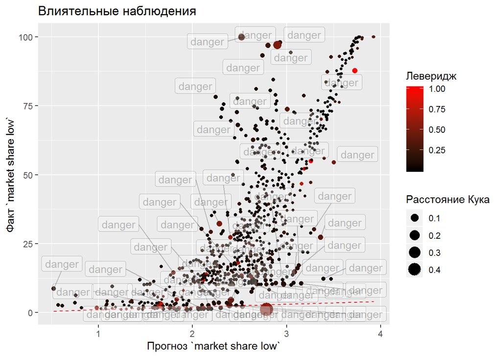

```r
m4a <- m4 %>%
  fortify() %>% # сохранили остатки, предсказания и показатели влиятельности в набор
  merge(., ail) # добавили исходные данные (merge удаляет дублирующиеся при слиянии столбцы)


ggplot(m4a, aes(.fitted, `market share low`)) +
  geom_point(aes(size = .cooksd, colour = .hat)) +
  geom_line(aes(.fitted, .fitted),
            colour = "red", linetype = "dashed") +
  scale_colour_gradient(low = "black", high = "red") +
  ggrepel::geom_label_repel(
    data = filter(m4a, .cooksd > 4/nrow(ail)),
    mapping = aes(label = "danger"), alpha = 0.25) +
  labs(title = "Влиятельные наблюдения",
       x = "Прогноз `market share low`", y = "Факт `market share low`",
       colour = "Леверидж", size = "Расстояние Кука")
```

Влиятельные наблюдения помечены словом “danger”, что говорит об опасности использзования данных наблюдений в моделе, которые негавтивно на нее влияют. Уберем выбросы и пересчитаем лучшие прогнозы и ошибки моделей.

```r
m4a$.cooksd <- as.numeric(m4a$.cooksd)
m4a$.cooksd[is.na(m4a$.cooksd)] <- mean(m4a$.cooksd, na.rm = T)
```

```r
m4a1 <- m4a %>%
  filter(.cooksd < 4/nrow(m4a))
```

Новые данные m4a1 не содержат выбросов.

Пересчет лучшие моделей 4, 4.1, 4.1.1 на “чистой” выборке:

```r
m4q <- lm(`market share low`^0.295 ~  `Low price airline`+
    `price low` + `market share leading`  + Distance + `market leading airline` +
    `Average Fare` + `Low price airline`*`market share leading` + `Low price airline`*Distance + `market share leading`*`market leading airline` , data = m4a1)


m41q <- lm(`market share low`^0.295 ~  `Low price airline`+
    `price low`  + Distance + `market leading airline` +
    `Average Fare` + `Low price airline`*`market share leading`  , data = m4a1)

m411q <- lm(`market share low`^0.309 ~  `Low price airline`+
    `price low`  + Distance + `market leading airline` +
    `Average Fare` + `Low price airline`*`market share leading`  , data = m4a1)

   pmcdl4q <-
  m4a1 %>%
  add_predictions(m4q, var = "Predicted") %>%
  dplyr::select(`market share low`, Predicted) %>%
   mutate(Predicted = Predicted^(1/0.295))

      pmcdl41q <-
  m4a1 %>%
  add_predictions(m41q, var = "Predicted") %>%
  dplyr::select(`market share low`, Predicted) %>%
   mutate(Predicted = Predicted^(1/0.295))

         pmcdl411q <-
  m4a1 %>%
  add_predictions(m411q, var = "Predicted") %>%
  dplyr::select(`market share low`, Predicted) %>%
   mutate(Predicted = Predicted^(1/0.309))
```

Расчет ошибок:

```r
all_models1 <-
  bind_rows(
          "4q" = pmcdl4q,
          "41q" = pmcdl41q,
          "411q" = pmcdl411q,

          .id = "Model")

all_models1 %>%
  group_by(Model) %>%
  summarise(errors = list(errors(`market share low`, Predicted))) %>%
  unnest() %>%
  arrange(MAPE) %>%
  knitr::kable()
```

[output not shown]

Для расчета прогноза на тестовом периоде будет использована модель 4q без выбросов.

#Прогнозирование на тестовом периоде

```r
pm9110 <-
  ait %>%
  add_predictions(m4q, var = "Predicted") %>%
 dplyr::select( `market share low`, Predicted) %>%
  mutate(Predicted = Predicted^(1/0.295))
```

```r
final <-
  bind_rows("test" = pm9110,

          .id = "Model")

final %>%

  summarise(errors = list(errors(`market share low`, Predicted))) %>%
  unnest() %>%

  knitr::kable()
```

| ME | MAE | MAPE | MSE | RMSE | BIAS |
| --- | --- | --- | --- | --- | --- |
| 0.607 | 16.8 | 0.938 | 537 | 23.2 | 0.015 |